# Log data in R

Steph Locke (@SteffLocke)

2017-04-07

# 1 Read log data

- readr::read_log is more forgiving than data.table::fread

```r
library(readr)
rawlogs<-read_log("https://raw.githubusercontent.com/elastic/examples/master/ElasticStack_apache/apache_logs")
library(data.table)
logs<-data.table(rawlogs)
knitr::kable(head(logs))
```

| X1 | X2 | X3 | X4 | X5 | X6 | X7 | X8 | X9 |
| --- | --- | --- | --- | --- | --- | --- | --- | --- |
| 83.149.9.216 | NA | NA | 17/May/2015:10:05:03 +0000 | GET /presentations/logstash-monitorama-2013/images/kibana-search.png HTTP/1.1 | 200 | 203023 | http://semicomplete.com/presentations/logstash-monitorama-2013/ | Mozilla/5.0 (Macintosh; Intel Mac OS X 10_9_1) AppleWebKit/537.36 (KHTML, like Gecko) Chrome/32.0.1700.77 Safari/537.36 |
| 83.149.9.216 | NA | NA | 17/May/2015:10:05:43 +0000 | GET /presentations/logstash-monitorama-2013/images/kibana-dashboard3.png HTTP/1.1 | 200 | 171717 | http://semicomplete.com/presentations/logstash-monitorama-2013/ | Mozilla/5.0 (Macintosh; Intel Mac OS X 10_9_1) AppleWebKit/537.36 (KHTML, like Gecko) Chrome/32.0.1700.77 Safari/537.36 |
| 83.149.9.216 | NA | NA | 17/May/2015:10:05:47 +0000 | GET /presentations/logstash-monitorama-2013/plugin/highlight/highlight.js HTTP/1.1 | 200 | 26185 | http://semicomplete.com/presentations/logstash-monitorama-2013/ | Mozilla/5.0 (Macintosh; Intel Mac OS X 10_9_1) AppleWebKit/537.36 (KHTML, like Gecko) Chrome/32.0.1700.77 Safari/537.36 |
| 83.149.9.216 | NA | NA | 17/May/2015:10:05:12 +0000 | GET /presentations/logstash-monitorama-2013/plugin/zoom-js/zoom.js HTTP/1.1 | 200 | 7697 | http://semicomplete.com/presentations/logstash-monitorama-2013/ | Mozilla/5.0 (Macintosh; Intel Mac OS X 10_9_1) AppleWebKit/537.36 (KHTML, like Gecko) Chrome/32.0.1700.77 Safari/537.36 |
| 83.149.9.216 | NA | NA | 17/May/2015:10:05:07 +0000 | GET /presentations/logstash-monitorama-2013/plugin/notes/notes.js HTTP/1.1 | 200 | 2892 | http://semicomplete.com/presentations/logstash-monitorama-2013/ | Mozilla/5.0 (Macintosh; Intel Mac OS X 10_9_1) AppleWebKit/537.36 (KHTML, like Gecko) Chrome/32.0.1700.77 Safari/537.36 |
| 83.149.9.216 | NA | NA | 17/May/2015:10:05:34 +0000 | GET /presentations/logstash-monitorama-2013/images/sad-medic.png HTTP/1.1 | 200 | 430406 | http://semicomplete.com/presentations/logstash-monitorama-2013/ | Mozilla/5.0 (Macintosh; Intel Mac OS X 10_9_1) AppleWebKit/537.36 (KHTML, like Gecko) Chrome/32.0.1700.77 Safari/537.36 |

## 1.1 Rename columns

Logs usually don’t have headers so you need to update the default column titles to something more expressive.

```r
setnames(logs, colnames(logs)
         ,c( "ip", "identd", "uname", "time", "request", "status", "respsize", "referer", "agent"))
# http://stackoverflow.com/questions/9234699/understanding-apache-access-log
#  %h is the remote host (ie the client IP)
# %l is the identity of the user determined by identd (not usually # used since not reliable)
# %u is the user name determined by HTTP authentication
# %t is the time the request was received.
# %r is the request line from the client. ("GET / HTTP/1.0")
# %>s is the status code sent from the server to the client (200, # 404 etc.)
# %b is the size of the response to the client (in bytes)
# Referer is the page that linked to this URL.
# User-agent is the browser identification string.

knitr::kable(head(logs))
```

| ip | identd | uname | time | request | status | respsize | referer | agent |
| --- | --- | --- | --- | --- | --- | --- | --- | --- |
| 83.149.9.216 | NA | NA | 17/May/2015:10:05:03 +0000 | GET /presentations/logstash-monitorama-2013/images/kibana-search.png HTTP/1.1 | 200 | 203023 | http://semicomplete.com/presentations/logstash-monitorama-2013/ | Mozilla/5.0 (Macintosh; Intel Mac OS X 10_9_1) AppleWebKit/537.36 (KHTML, like Gecko) Chrome/32.0.1700.77 Safari/537.36 |
| 83.149.9.216 | NA | NA | 17/May/2015:10:05:43 +0000 | GET /presentations/logstash-monitorama-2013/images/kibana-dashboard3.png HTTP/1.1 | 200 | 171717 | http://semicomplete.com/presentations/logstash-monitorama-2013/ | Mozilla/5.0 (Macintosh; Intel Mac OS X 10_9_1) AppleWebKit/537.36 (KHTML, like Gecko) Chrome/32.0.1700.77 Safari/537.36 |
| 83.149.9.216 | NA | NA | 17/May/2015:10:05:47 +0000 | GET /presentations/logstash-monitorama-2013/plugin/highlight/highlight.js HTTP/1.1 | 200 | 26185 | http://semicomplete.com/presentations/logstash-monitorama-2013/ | Mozilla/5.0 (Macintosh; Intel Mac OS X 10_9_1) AppleWebKit/537.36 (KHTML, like Gecko) Chrome/32.0.1700.77 Safari/537.36 |
| 83.149.9.216 | NA | NA | 17/May/2015:10:05:12 +0000 | GET /presentations/logstash-monitorama-2013/plugin/zoom-js/zoom.js HTTP/1.1 | 200 | 7697 | http://semicomplete.com/presentations/logstash-monitorama-2013/ | Mozilla/5.0 (Macintosh; Intel Mac OS X 10_9_1) AppleWebKit/537.36 (KHTML, like Gecko) Chrome/32.0.1700.77 Safari/537.36 |
| 83.149.9.216 | NA | NA | 17/May/2015:10:05:07 +0000 | GET /presentations/logstash-monitorama-2013/plugin/notes/notes.js HTTP/1.1 | 200 | 2892 | http://semicomplete.com/presentations/logstash-monitorama-2013/ | Mozilla/5.0 (Macintosh; Intel Mac OS X 10_9_1) AppleWebKit/537.36 (KHTML, like Gecko) Chrome/32.0.1700.77 Safari/537.36 |
| 83.149.9.216 | NA | NA | 17/May/2015:10:05:34 +0000 | GET /presentations/logstash-monitorama-2013/images/sad-medic.png HTTP/1.1 | 200 | 430406 | http://semicomplete.com/presentations/logstash-monitorama-2013/ | Mozilla/5.0 (Macintosh; Intel Mac OS X 10_9_1) AppleWebKit/537.36 (KHTML, like Gecko) Chrome/32.0.1700.77 Safari/537.36 |

# 2 Time handling

There is date handling capability out of the box with R, however, the lubridate package makes it easier to convert strings to dates, and perform manipulations.

```r
library(lubridate)
logs[,time:=dmy_hms(time)]
logs[,`:=`(hour=hour(time), wday=wday(time)
           ,morning=am(time))]
logs[ , weekend:= wday %in% c(1,7)]
```

# 3 Geolocation packages

There are few packages for resolving IPs: - rgeolocate - ggmap - iptools - ipapi (gh: hrbrmstr/ipapi)

Which one to use depends on API preferences, plus any additional requirements.

> Play it smart - don’t call for every record, call for every unique record. Cache values where possible!

```r
if(!require(ipapi)) devtools::install_github("hrbrmstr/ipapi")
```

[output not shown]

```
## from URL https://api.github.com/repos/hrbrmstr/ipapi/zipball/master
```

```
## Installing ipapi
```

[output not shown]

[output not shown]

[output not shown]

```r
library(ipapi)
ips<-logs[,unique(ip)]

example<-TRUE
iptblloc<-"https://raw.githubusercontent.com/stephlocke/lazyCDN/master/sampleIPtbl.csv"

ip_tbl<-if(example) fread(iptblloc)

#ip_tbl<- ipapi::geolocate(ips)[, status:=NULL]

# Join IP results to log data
logs<-logs[ip_tbl, on=c(ip="query")]
head(logs)
```

```
##              ip identd uname                time
## 1: 83.149.9.216     NA    NA 2015-05-17 10:05:03
## 2: 83.149.9.216     NA    NA 2015-05-17 10:05:43
## 3: 83.149.9.216     NA    NA 2015-05-17 10:05:47
## 4: 83.149.9.216     NA    NA 2015-05-17 10:05:12
## 5: 83.149.9.216     NA    NA 2015-05-17 10:05:07
## 6: 83.149.9.216     NA    NA 2015-05-17 10:05:34
##                                                                               request
## 1:      GET /presentations/logstash-monitorama-2013/images/kibana-search.png HTTP/1.1
## 2:  GET /presentations/logstash-monitorama-2013/images/kibana-dashboard3.png HTTP/1.1
## 3: GET /presentations/logstash-monitorama-2013/plugin/highlight/highlight.js HTTP/1.1
## 4:        GET /presentations/logstash-monitorama-2013/plugin/zoom-js/zoom.js HTTP/1.1
## 5:         GET /presentations/logstash-monitorama-2013/plugin/notes/notes.js HTTP/1.1
## 6:          GET /presentations/logstash-monitorama-2013/images/sad-medic.png HTTP/1.1
##    status respsize
```

[output cut: 41 more lines]

# 4 URL handling

The format of the Apache request log means that the request component needs splitting up. The values are not always in quite the right format so you should always check for errors.

```r
logs[,c("verb","url","scheme"):=tstrsplit(request," ")[1:3]]

# isolate issues!
issues<-logs[,!((verb %like% "^[A-Z]{3,}$")&
                 (scheme %like% "^HTTP"))]
errors<-logs[issues,]
logs<-logs[!issues, ]
```

```r
library(urltools)
logs[,c("path","params"):=.(path(url),parameters(url))]
```

# 5 Event steps

Often you need to worry about steps taken over time. The data.table package gives you an easy way to add IDs to rows or groups.

```r
logs[order(time),`:=`(order=.SD[,.I], visit=.GRP), .(ip,agent)]
```

## 5.1 Most common landing pages

```r
knitr::kable(logs[order==1,.N,path][
  order(-N)[1:10],])
```

| path | N |
| --- | --- |
| favicon.ico | 221 |
| NA | 145 |
| presentations/logstash-scale11x/images/ahhh___rage_face_by_samusmmx-d5g5zap.png | 112 |
| images/web/2009/banner.png | 95 |
| reset.css | 91 |
| style2.css | 91 |
| images/googledotcom.png | 89 |
| robots.txt | 79 |
| images/jordan-80.png | 73 |
| projects/xdotool/xdotool.xhtml | 54 |

## 5.2 Most common exit pages

```r
knitr::kable(logs[,.SD[which.max(order)],visit][
  ,.N,path][order(-N)[1:10],])
```

| path | N |
| --- | --- |
| favicon.ico | 215 |
| NA | 149 |
| presentations/logstash-scale11x/images/ahhh___rage_face_by_samusmmx-d5g5zap.png | 111 |
| images/googledotcom.png | 94 |
| images/jordan-80.png | 90 |
| images/web/2009/banner.png | 90 |
| style2.css | 83 |
| robots.txt | 75 |
| reset.css | 63 |
| projects/xdotool/xdotool.xhtml | 63 |

## 5.3 Most common bounce pages

```r
knitr::kable(logs[,.SD[which.max(order)],visit][
  order==1,.N,path][order(-N)[1:10],])
```

| path | N |
| --- | --- |
| presentations/logstash-scale11x/images/ahhh___rage_face_by_samusmmx-d5g5zap.png | 105 |
| images/googledotcom.png | 89 |
| favicon.ico | 67 |
| NA | 62 |
| robots.txt | 43 |
| presentations/logstash-scale11x/images/logstash.png | 18 |
| projects/xdotool/ | 15 |
| images/jordan-80.png | 11 |
| articles/dynamic-dns-with-dhcp/ | 11 |
| blog/geekery/ssl-latency.html | 10 |

## 5.4 Most common error pages

```r
logs[status>=500, .N, .(path,status)][order(-N)[1:pmin(10, .N)]]
```

```
##                  path status N
## 1: misc/Title.php.txt    500 2
## 2:  projects/xdotool/    500 1
```

## 5.5 Time since last request

```r
logs[order(order), timesinceprevrequest:= time - shift(time) , visit]
logs[visit==1, .(order, time, timesinceprevrequest )]
```

```
##     order                time timesinceprevrequest
##  1:     2 2015-05-17 10:05:03               3 secs
##  2:    14 2015-05-17 10:05:43               9 secs
##  3:    16 2015-05-17 10:05:47               1 secs
##  4:     5 2015-05-17 10:05:12               1 secs
##  5:     3 2015-05-17 10:05:07               4 secs
##  6:    13 2015-05-17 10:05:34               1 secs
##  7:    22 2015-05-17 10:05:57               1 secs
##  8:    17 2015-05-17 10:05:50               3 secs
##  9:     7 2015-05-17 10:05:24               5 secs
## 10:    18 2015-05-17 10:05:50               0 secs
## 11:    15 2015-05-17 10:05:46               3 secs
## 12:     4 2015-05-17 10:05:11               4 secs
## 13:     6 2015-05-17 10:05:19               7 secs
## 14:    11 2015-05-17 10:05:33               3 secs
## 15:     1 2015-05-17 10:05:00              NA secs
## 16:     9 2015-05-17 10:05:25               1 secs
## 17:    23 2015-05-17 10:05:59               2 secs
## 18:    10 2015-05-17 10:05:30               5 secs
## 19:    19 2015-05-17 10:05:53               3 secs
## 20:     8 2015-05-17 10:05:24               0 secs
## 21:    20 2015-05-17 10:05:54               1 secs
## 22:    12 2015-05-17 10:05:33               0 secs
## 23:    21 2015-05-17 10:05:56               2 secs
##     order                time timesinceprevrequest
```

# 6 Visualising

## 6.1 Mapping

```r
library(ggmap)
```

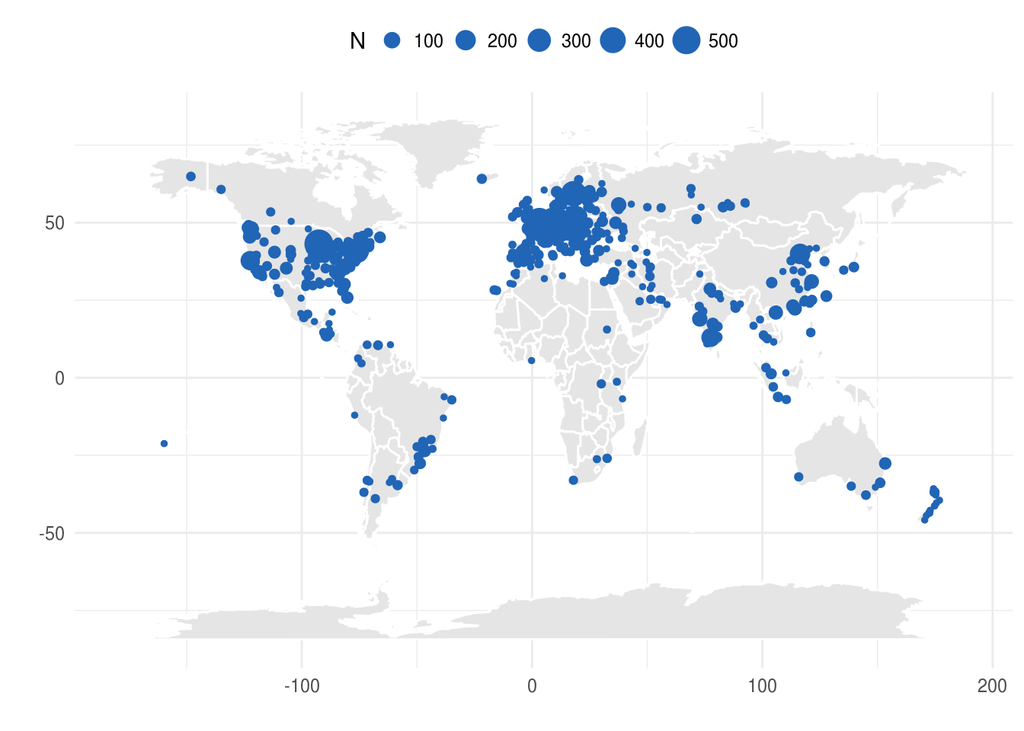

```r
ggplot(map_data('world')) +
  geom_polygon(aes(x = long, y = lat, group = group), fill = 'grey90', colour = 'white') +
geom_point(aes(x = lon, y = lat, size = N), color = '#2165B6',
           data = logs[, .N, .(lon, lat)]) +
  xlab('') + ylab('') +
  theme_minimal() + theme('legend.position' = 'top')
```

## 6.2 Heatmap

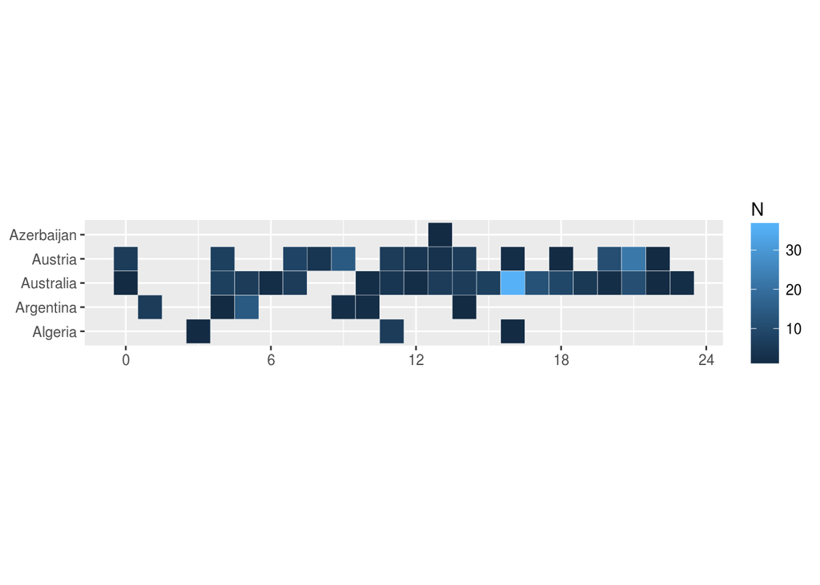

```r
library(ggplot2)

heatmap<-function(ggplot,size=20){
  ggplot+ coord_equal()+
    geom_tile(color="white", size=0.1)+
    labs(x=NULL, y=NULL, title=NULL)+
    scale_x_continuous(breaks=seq(0,24,6))+
    scale_fill_gradient()
}

ip_activity<-logs[,.N,.(country,hour)]
ga<-ggplot(ip_activity[country %like% "^A"], aes(x=hour, y=country, fill=N))
heatmap(ga)
```

## 6.3 Flow Diagram

```r
library(DiagrammeR)

URLids<-logs[,.N,.(labels_col=path)][,nodes:=.I][N>50]
activity<-URLids[logs, on=c(labels_col="path")][
  !is.na(nodes),.(visit, order, nodes)]

# Get a cross join of activity
moves<-activity[activity, on=c("visit"), allow.cartesian=TRUE][
  # Filter to only include next site
  order==i.order-1][
    # Get nodes and position
    ,.(tooltip=.N),.(from=nodes,to=i.nodes)][,penwidth:=10*tooltip/max(tooltip)]

## Bug in DiagrammeR latest v :-/
#
#gr<-create_graph(URLids, moves)
#
#render_graph(gr)
```

# 7 Time series

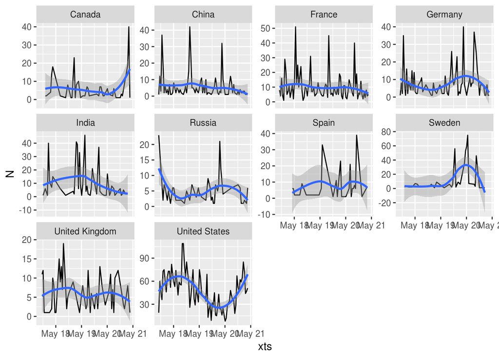

```r
top10<-logs[,.N,country][order(-N)[1:10],country]
tz_ts<-logs[country %in% top10,.N,.(country, xts::align.time(time,n=60*5))]
ggplot(tz_ts, aes(x=xts, y=N, group=1))+
  geom_line()+
  geom_smooth()+
  facet_wrap(~country, scales="free_y")
```

```r
library(xts)
```

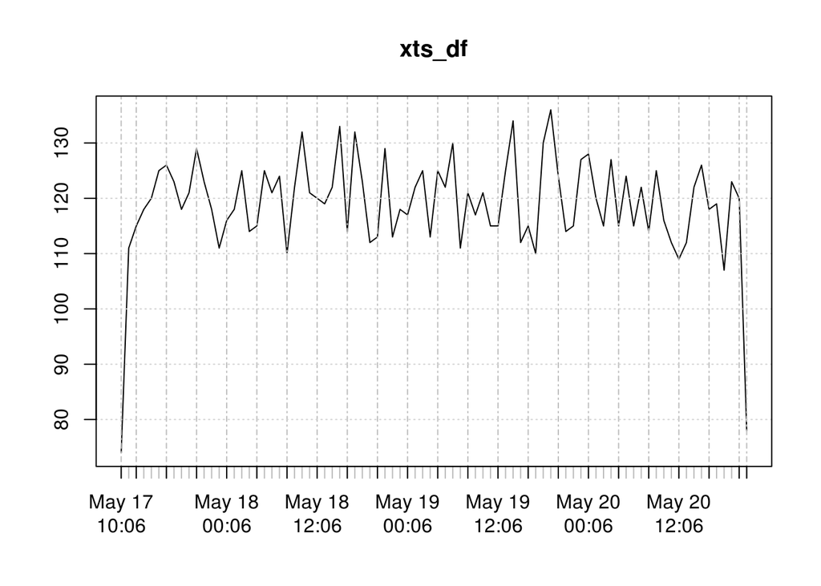

```r
ts<-logs[order(time),.N,.(time=xts::align.time(time,n=60))]
xts_df<-xts(ts$N,ts$time)
plot(xts_df)
```

```r
devtools::install_github("twitter/AnomalyDetection")
```

```
## $anoms
##             timestamp anoms
## 1 2015-05-17 10:06:00    74
## 2 2015-05-18 10:06:00   132
## 3 2015-05-19 14:06:00   134
## 4 2015-05-20 21:06:00    78
##
## $plot
```

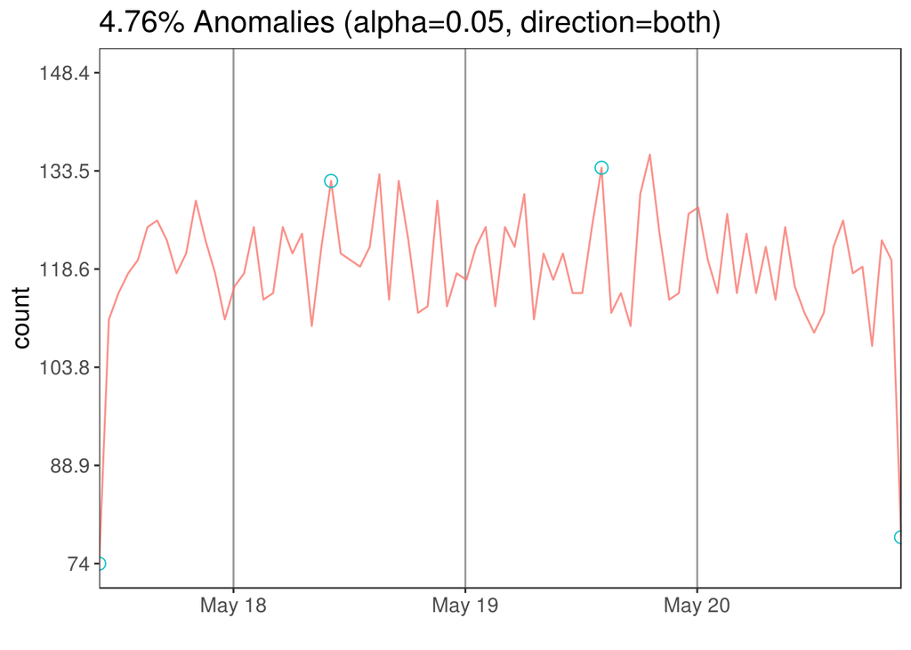

```r
library(AnomalyDetection)
AnomalyDetectionTs(setDF(logs[,.N,align.time(time)]), max_anoms=0.05, direction='both',plot=TRUE)
```